# DGE using VDJ features

2023-09-01

## Overview

Combing the metadata from the VDJ assay with the `FindMarkers()` function from `Seurat` permits differential gene expression (DGE) comparisons using the VDJ features such as expanded vs. unexpanded clones, comparing clones/clonotypes to each other, or comparing groups of cells with particular shared VDJ features like V isotype or germline gene usage.

The R markdown script for this workflow is available on [github](https://raw.githubusercontent.com/kjlj/scRNA-seq_VDJ/main/docs/dge_using_VDJ_features.Rmd) in the [workshop respository](https://github.com/kjlj/scRNA-seq_VDJ).

### R packages

For this need the [Seurat](https://github.com/satijalab/seurat) package, the [tidyverse](https://www.tidyverse.org/) packages, [ggsci](https://cran.r-project.org/web/packages/ggsci/vignettes/ggsci.html) for colour palettes and [ggrepel](https://cran.r-project.org/web/packages/ggrepel/vignettes/ggrepel.html) for repelling labels from data points on the ‘volcano’ plots.

```r
#packages

#check if the package is already installed, if not, install it
if (sum(grepl("Seurat", rownames(installed.packages()))) > 0) {
  print("tidyverse is already installed")
} else {
  install.packages("Seurat")
}
```

```
## [1] "tidyverse is already installed"
```

```r
#loading R packages
library(Seurat)
#check if the package is already installed, if not, install it
if (sum(grepl("tidyverse", rownames(installed.packages()))) > 0) {
  print("tidyverse is already installed")
} else {
  install.packages("tidyverse")
}
```

```
## [1] "tidyverse is already installed"
```

```r
#loading R packages
library(tidyverse)
#check if the package is already installed, if not, install it
if (sum(grepl("ggsci", rownames(installed.packages()))) > 0) {
  print("ggsci is already installed")
} else {
  install.packages("ggsci")
}
```

```
## [1] "ggsci is already installed"
```

```r
#loading R packages
library(ggsci)

#check if the package is already installed, if not, install it
if (sum(grepl("ggrepel", rownames(installed.packages()))) > 0) {
  print("ggrepel is already installed")
} else {
  install.packages("ggrepel")
}
```

```
## [1] "ggrepel is already installed"
```

```r
#loading R packages
library(ggrepel)
```

### Themes for plotting

Custom themes for ggplot2:

```r
#themes for plots
theme_custom <- function (base_size = 12) {
  theme_bw(base_size=base_size) %+replace%
    theme(panel.grid = element_blank(),
          panel.border = element_blank(),
          axis.line = element_line(colour="black"),
          axis.text.x = element_text(colour="black", size=base_size),
          axis.text.y = element_text(colour="black", size = base_size, hjust = 1),
          axis.title = element_text(colour="black", face="bold", size = base_size),
          strip.background = element_blank(),
          strip.text = element_text(colour="black", face="bold", size=base_size),
          legend.text = element_text(colour="black", size=base_size)
    )
}

theme_x_rotated <- function (base_size = 12) {
  theme_custom(base_size=base_size) %+replace%
    theme(axis.text.x = element_text(colour="black", angle = 90, hjust = 1, vjust = 0.5, size=base_size))
}
```

## Loading datasets

Loading the Seurat object plus the metadata:

```r
#loading seurat object
tumour.seurat.obj <- readRDS("../seurat_objects/tumour_seurat-without-VDJ-genes-azimuth.rds")

#loading the seurat exported data
seurat.data <- read_tsv("../data/pbmc-tumour_seruat_data.tsv")
```

Adding metadata to the Seurat object:

```r
#add the metadata to seurat object
metadata <- as.data.frame(seurat.data %>% filter(dataset == "tumour"))
rownames(metadata) <- metadata$barcode
metadata <- metadata %>% select(-barcode)

tumour.seurat.obj <- AddMetaData(tumour.seurat.obj, metadata)
```

## Comparing gene markers between different groups of cells

Quick plot of some of the Azimuth annotation on the UMAP:

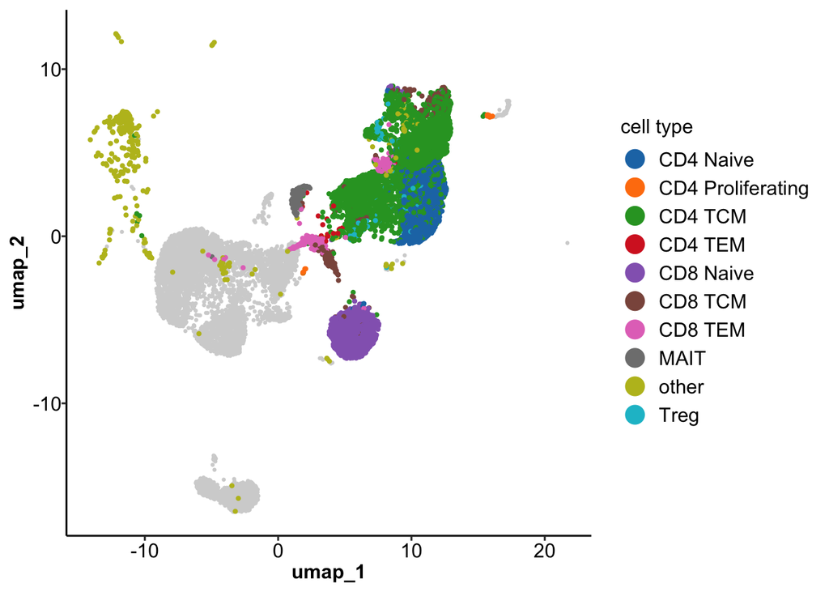

```r
#umap of T subsets cells by Azimuth annotation
azimuth_levels <- c(unique(seurat.data$azimuth_l2)[grepl("^CD[4|8]", unique(seurat.data$azimuth_l2))], "MAIT", "Treg")

#add to the data
seurat.data <- seurat.data %>%
  mutate(cell_type = ifelse(azimuth_l2 %in% azimuth_levels, paste(azimuth_l2), "other"))

#plotting
p1 <- ggplot(seurat.data,
       aes(x = umap_1, y = umap_2)) +
  geom_point(data = seurat.data %>% filter(vdj_cell_type != "T"),
             size = 0.5, colour = "lightgray") +
  geom_point(data = seurat.data %>% filter(vdj_cell_type == "T"),
             size = 0.8,
             aes(colour = cell_type)) +
  scale_colour_d3(palette = "category20",
                  name = "cell type") +
  theme_custom() +
  guides(colour = guide_legend(override.aes = list(size = 5)))
print(p1)
```

The `FindMarkers()` function from the Seurat package can be used for comparing gene expression between groups of cells.

We have the T cell annotation from Azimuth, so can use this to do a basic comparison between cells from the naive and central memory populations within the CD4s. To do this the `FindMarkers()` function is called with ‘azimuth_l2’ as the grouping (is the `group.by` argument) and then `ident.1` and `ident.2` are used to set the labels for the azimuth_l2 that are to be compared, here `ident.1` is set to “CD4 Naive” and `ident.2` to the “CD4 TCM”:

```r
cd4naive.vs.cd4tcm.markers <- FindMarkers(tumour.seurat.obj,
                                          group.by = "azimuth_l2",
                                          ident.1 = "CD4 Naive", ident.2 = "CD4 TCM") %>%
  rownames_to_column("gene") %>%
  arrange(desc(avg_log2FC))

#filter for significance and print the top genes by logFC
cd4naive.vs.cd4tcm.markers %>%
  filter(p_val_adj < 0.05) %>%
  head()
```

```
##         gene        p_val avg_log2FC pct.1 pct.2    p_val_adj
## 1      FCGRT 3.863042e-07   2.547637 0.833 0.134 7.683204e-03
## 2      ZFP14 1.082460e-14   2.455476 0.667 0.038 2.152904e-10
## 3   TMEM229B 5.947969e-08   2.327476 0.333 0.020 1.182991e-03
## 4 AC009061.2 6.571361e-07   2.269694 0.333 0.023 1.306978e-02
## 5     KCNMB4 1.415440e-06   2.253602 0.333 0.024 2.815169e-02
## 6      FANCF 1.445704e-11   2.190968 0.500 0.028 2.875360e-07
```

In addition to the tabular format, we can use the output to create volcano-style plots:

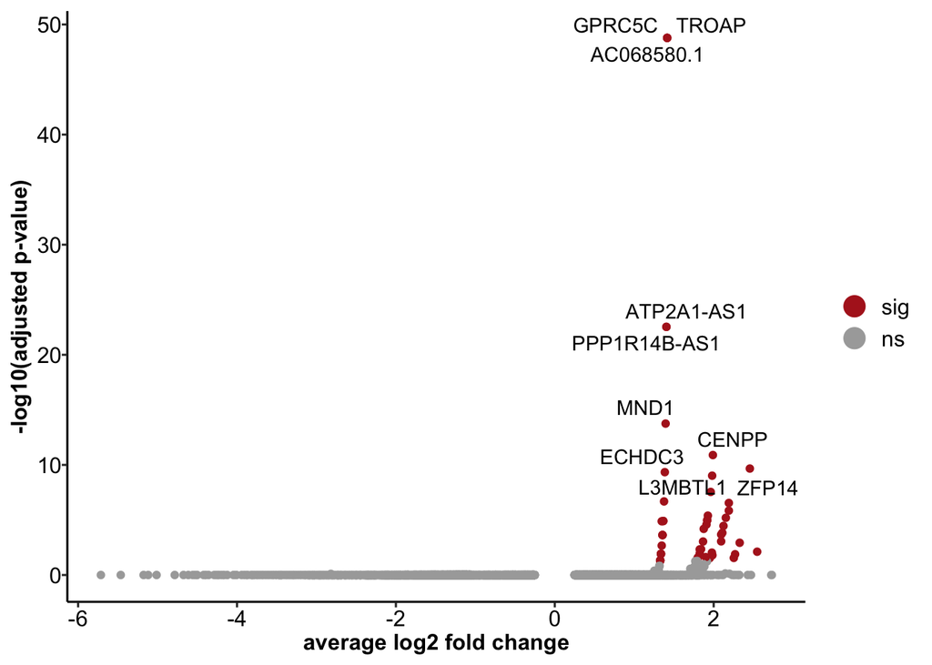

```r
#show as a volcano plot
p1 <- ggplot(cd4naive.vs.cd4tcm.markers,
       aes(x = avg_log2FC, y = -log10(p_val_adj))) +
  geom_point(aes(colour = ifelse(p_val_adj < 0.05, "sig", "ns"))) +
  geom_text_repel(aes(label = ifelse(p_val_adj < 0.05, gene, NA))) +
  theme_custom() +
  scale_colour_manual(values = c("firebrick", "darkgray"),
                      name = "",
                      limits = c("sig", "ns")) +
  guides(colour = guide_legend(override.aes = list(size = 5))) +
  labs(x = "average log2 fold change",
       y = "-log10(adjusted p-value)")
plot(p1)
```

Next we will explore an example comparing the expanded versus singleton clones within the T cells. To do this we used the ‘t_expanded_cln’ column as the `group.by` and `ident.1` and `ident.2` as ‘expanded’ and ‘singleton’, respectively.

```r
#can compare expanded versus singleton clones
texp.vs.tsingle.markers <- FindMarkers(tumour.seurat.obj,
                                          group.by = "t_expanded_cln",
                                          ident.1 = "expanded", ident.2 = "singleton") %>%
  rownames_to_column("gene") %>%
  arrange(desc(avg_log2FC))

#printing top genes
texp.vs.tsingle.markers %>%
  filter(p_val_adj < 0.05) %>%
  head()
```

```
##       gene        p_val avg_log2FC pct.1 pct.2    p_val_adj
## 1   CXCL13 1.118672e-30   3.850364 0.244 0.012 2.224927e-26
## 2    MKI67 2.498171e-08   3.167408 0.133 0.017 4.968612e-04
## 3     GNG4 6.819908e-41   3.103852 0.400 0.026 1.356412e-36
## 4 C11orf96 1.061750e-07   3.071674 0.178 0.031 2.111714e-03
## 5    PDCD1 3.389794e-21   2.987118 0.556 0.109 6.741960e-17
## 6     CCL4 1.168497e-06   2.978320 0.200 0.044 2.324023e-02
```

The volcono plot for comparing gene markers between the expanded T cells and singleton T cells:

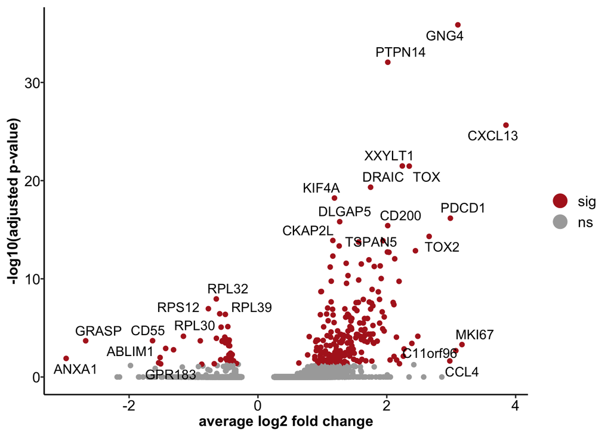

```r
#show as a volcano plot
p1 <- ggplot(texp.vs.tsingle.markers,
       aes(x = avg_log2FC, y = -log10(p_val_adj))) +
  geom_point(aes(colour = ifelse(p_val_adj < 0.05, "sig", "ns"))) +
  geom_text_repel(aes(label = ifelse(p_val_adj < 0.05, gene, NA))) +
  theme_custom() +
  scale_colour_manual(values = c("firebrick", "darkgray"),
                      name = "",
                      limits = c("sig", "ns")) +
  guides(colour = guide_legend(override.aes = list(size = 5))) +
  labs(x = "average log2 fold change",
       y = "-log10(adjusted p-value)")
plot(p1)
```

```r
no1.vs.no2.markers <- FindMarkers(tumour.seurat.obj,
                                       group.by = "t_cln_rnk",
                                       ident.1 = "1", ident.2 = "2") %>%
  rownames_to_column("gene") %>%
  arrange(desc(avg_log2FC))

no1.vs.no2.markers %>% head()
```

```
##       gene      p_val avg_log2FC pct.1 pct.2 p_val_adj
## 1     RGCC 0.02727159   5.588298 0.833   0.2         1
## 2     HES4 0.01629747   5.235216 0.833   0.0         1
## 3 IVNS1ABP 0.10406218   4.790077 0.500   0.0         1
## 4    ISG15 0.01629747   4.700440 0.833   0.0         1
## 5     SC5D 0.04390199   4.700440 0.667   0.0         1
## 6    TRAF1 0.22299386   4.700440 0.333   0.0         1
```

```r
no1.vs.no2.markers %>%
  filter(p_val_adj < 0.05) %>%
  head()
```

```
## [1] gene       p_val      avg_log2FC pct.1      pct.2      p_val_adj
## <0 rows> (or 0-length row.names)
```

No markers to differentiate between the top 2 T cell clonotypes were found.

The comparison need not be limited to one vs one. You can use vectors for `ident.1` and `ident.2` to create groups that span multiple categories with the feature.

```r
## this will compare the clones ranked 1 and 2 with those ranked 3 - 5
grp1.vs.grp2.markers <- FindMarkers(tumour.seurat.obj,
                                  group.by = "t_cln_rnk",
                                  ident.1 = c("1", "2"), ident.2 = c("3", "5")) %>%
  rownames_to_column("gene") %>%
  arrange(desc(avg_log2FC))

grp1.vs.grp2.markers %>% head()
```

```
##     gene        p_val avg_log2FC pct.1 pct.2 p_val_adj
## 1   CCL4 4.053059e-01   4.609347 0.273 0.176 1.0000000
## 2   IFNG 3.400476e-02   3.926998 0.364 0.118 1.0000000
## 3  S1PR1 6.300138e-06   2.676394 0.636 0.029 0.1253035
## 4 PHLDA2 1.899261e-01   2.667560 0.182 0.059 1.0000000
## 5  TAF4B 1.759629e-03   2.667560 0.455 0.059 1.0000000
## 6  FSCN1 4.448663e-02   2.667560 0.273 0.059 1.0000000
```

```r
grp1.vs.grp2.markers %>%
  filter(p_val_adj < 0.05) %>%
  head()
```

```
## [1] gene       p_val      avg_log2FC pct.1      pct.2      p_val_adj
## <0 rows> (or 0-length row.names)
```

In this case, there were not genes that differentiate the clonotype groups.

Any of the metadata columns that contain categorical data can be used, for example, we can compare the gene expression between B cells that utilise different IGVH genes.

To do so, ‘v_igh’ becomes the `group.by` and two IGHV genes are specified for `ident.1` and `ident.2`. In this case, we are comparing IGHV1-69 expressing B cells to those utilising IGHV3-23:

```r
vgene1.vs.vgene2.markers <- FindMarkers(tumour.seurat.obj,
                                    group.by = "v_igh",
                                    ident.1 = c("IGHV1-69"), ident.2 = c("IGHV3-23")) %>%
  rownames_to_column("gene") %>%
  arrange(desc(avg_log2FC))

vgene1.vs.vgene2.markers %>% head()
```

```
##     gene        p_val avg_log2FC pct.1 pct.2    p_val_adj
## 1   ZHX3 1.450246e-03  0.6090240 0.123 0.061 1.000000e+00
## 2   GMFB 4.065036e-04  0.6066748 0.318 0.218 1.000000e+00
## 3   LRMP 4.059982e-03  0.5946276 0.408 0.329 1.000000e+00
## 4  TRAK2 1.573577e-04  0.5924547 0.226 0.128 1.000000e+00
## 5   IGHM 3.283563e-11  0.5807717 0.827 0.694 6.530678e-07
## 6 ZBTB16 1.238991e-04  0.5620941 0.187 0.094 1.000000e+00
```

```r
vgene1.vs.vgene2.markers %>%
  filter(p_val_adj < 0.05) %>%
  head()
```

```
##      gene        p_val avg_log2FC pct.1 pct.2    p_val_adj
## 1    IGHM 3.283563e-11  0.5807717 0.827 0.694 6.530678e-07
## 2   PLPP5 1.426832e-06  0.5416449 0.701 0.553 2.837825e-02
## 3   RFTN1 1.433010e-07  0.5109478 0.701 0.545 2.850114e-03
## 4   FCER2 2.043922e-10  0.4678203 0.899 0.734 4.065157e-06
## 5    YBX3 3.612826e-07  0.4218897 0.763 0.577 7.185549e-03
## 6 HLA-DMA 3.727906e-08  0.3427620 0.980 0.933 7.414433e-04
```

View on a volcano style plot:

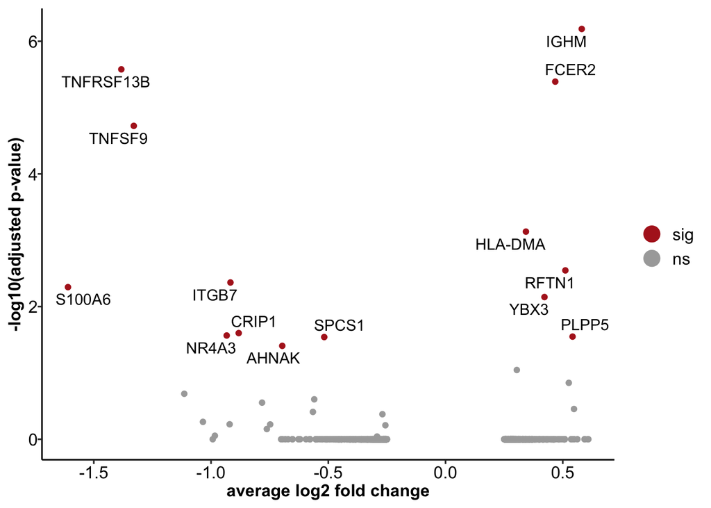

```r
p1 <- ggplot(vgene1.vs.vgene2.markers,
             aes(x = avg_log2FC, y = -log10(p_val_adj))) +
  geom_point(aes(colour = ifelse(p_val_adj < 0.05, "sig", "ns"))) +
  geom_text_repel(aes(label = ifelse(p_val_adj < 0.05, gene, NA))) +
  theme_custom() +
  scale_colour_manual(values = c("firebrick", "darkgray"),
                      name = "",
                      limits = c("sig", "ns")) +
  guides(colour = guide_legend(override.aes = list(size = 5))) +
  labs(x = "average log2 fold change",
       y = "-log10(adjusted p-value)")
plot(p1)
```

Based on the comparison IgM and FCER2 more common among IGHV1-69 utilising B cells which may suggest that this gene is more commonly utilised in naive cells compared to IGHV3-23.

[Return to main page](https://kjlj.github.io/scRNA-seq_VDJ/)